# Bryan_DAmico_HW2

2022-10-15

## Introduction

The education system in the United States has gradually undergone a standardization process with the goal of providing students with similar and equitable educational opportunities, regardless of where they live and go to school. As part of this effort, five different schools have employed the same math course during the current semester. This course consists of 35 lessons where students are expected to be completing lessons according to a pre-determined schedule. The schools are interested in seeing the differences in how far the students have progressed in each section of the course offered. The semester is approximately 75% of the way through at the time that the analysis request was made.

When implementing the same course over many sections and at different schools, it is important to ensure that the experience is as similar as possible for all students. Since each student is getting a grade and credit for the same class, a student who receives a B at one school should be demonstrating a similar level of content mastery as another student who receives a B at a different school. One way to check if the difficulty of the course is consistent between sections and schools is to see how far students are progressing through the course. If the course was much more difficult at one of the schools, it would stand to reason that a greater proportion of students would be behind in their work at this school than at the other schools.

The main objective of the analysis is to uncover the story that is being told by the data. The focus will be on students’ progress in the course. How far ahead or behind students are in the curriculum should paint a picture of the fairness of the implementation of the course. The results of this analysis will clearly inform each school how their students are performing and provide rationale for any changes that should be made to how they are deploying the course. Two questions will be the main focus: (1) Are the students in the different schools performing similarly? (2) Is class size correlated to the progress of the students in that section?

## Analysis and Models

### About the Data

The following packages were loaded to read in the data and perform the analysis.

```r
#Loading the packages required for the analysis.
library(tidyverse)
library(reshape2)

#Reading in the data set.
storyteller <- read_csv("~/Documents/Syracuse/Quarter 2/Applied Machine Learning/Homeworks/Homework 2/data_storyteller.csv")
```

This data set contains information about the progress of students taking the same math course this semester across 30 sections administered by 5 different schools. The following output displays each of the variables in the data set along with their data type.

```r
#Explore the structure of the data set.
str(storyteller)
```

```
## spec_tbl_df [30 × 8] (S3: spec_tbl_df/tbl_df/tbl/data.frame)
##  $ School           : chr [1:30] "A" "A" "A" "A" ...
##  $ Section          : num [1:30] 1 2 3 4 5 6 7 8 9 10 ...
##  $ Very Ahead +5    : num [1:30] 0 0 0 0 0 0 0 0 0 0 ...
##  $ Middling +0      : num [1:30] 5 8 9 14 9 7 19 3 6 13 ...
##  $ Behind -1-5      : num [1:30] 54 40 35 44 42 29 22 37 29 40 ...
##  $ More Behind -6-10: num [1:30] 3 10 12 5 2 3 5 11 8 5 ...
##  $ Very Behind -11  : num [1:30] 9 16 13 12 24 10 14 18 12 5 ...
##  $ Completed        : num [1:30] 10 6 11 10 8 9 19 5 10 20 ...
##  - attr(*, "spec")=
##   .. cols(
##   ..   School = col_character(),
##   ..   Section = col_double(),
##   ..   `Very Ahead +5` = col_double(),
##   ..   `Middling +0` = col_double(),
##   ..   `Behind -1-5` = col_double(),
##   ..   `More Behind -6-10` = col_double(),
##   ..   `Very Behind -11` = col_double(),
##   ..   Completed = col_double()
##   .. )
##  - attr(*, "problems")=<externalptr>
```

Each of the 5 schools is assigned a letter from A to E. Each of the schools has a number of class sections, numbered sequentially. For example, school A has 13 sections, so they are numbered 1 to 13. Note that the numbering resets for each new school. Since school B has 12 sections those are numbered 1 to 12. Each data point for the rest of the variables is a count of how many students in the section are in that progress category. For example, if the column ‘Very Ahead +5’ has an entry of 10, that means 10 students in that section are more than 5 lessons ahead.

There are some initial problems with the data set upon reading it in. The data in the School and Section columns should be regarded as factors because they categorize the data into different groups. Also, each of the numeric variables should be integers because they are counting people, which means there will only be whole numbers.

```r
#Setting the School and Section variables to be factor variables.
storyteller$School <- as.factor(storyteller$School)
storyteller$Section <- as.factor(storyteller$Section)

#The rest of the variables should be discrete integers since they are recording whole numbers.
storyteller$'Very Ahead +5' <- as.integer(storyteller$'Very Ahead +5') #More than 5 lessons ahead
storyteller$'Middling +0' <- as.integer(storyteller$'Middling +0') #5 lessons ahead to 0 lessons ahead
storyteller$'Behind -1-5' <- as.integer(storyteller$'Behind -1-5') #1 to 5 lessons behind
storyteller$'More Behind -6-10' <- as.integer(storyteller$'More Behind -6-10') #6 to 10 lessons behind
storyteller$'Very Behind -11' <- as.integer(storyteller$'Very Behind -11') #More than 10 lessons behind
storyteller$Completed <- as.integer(storyteller$Completed) #Finished with the course

#Checking to see that all changes have been implemented correctly.
str(storyteller)
```

```
## spec_tbl_df [30 × 8] (S3: spec_tbl_df/tbl_df/tbl/data.frame)
##  $ School           : Factor w/ 5 levels "A","B","C","D",..: 1 1 1 1 1 1 1 1 1 1 ...
##  $ Section          : Factor w/ 13 levels "1","2","3","4",..: 1 2 3 4 5 6 7 8 9 10 ...
##  $ Very Ahead +5    : int [1:30] 0 0 0 0 0 0 0 0 0 0 ...
##  $ Middling +0      : int [1:30] 5 8 9 14 9 7 19 3 6 13 ...
##  $ Behind -1-5      : int [1:30] 54 40 35 44 42 29 22 37 29 40 ...
##  $ More Behind -6-10: int [1:30] 3 10 12 5 2 3 5 11 8 5 ...
##  $ Very Behind -11  : int [1:30] 9 16 13 12 24 10 14 18 12 5 ...
##  $ Completed        : int [1:30] 10 6 11 10 8 9 19 5 10 20 ...
##  - attr(*, "spec")=
##   .. cols(
##   ..   School = col_character(),
##   ..   Section = col_double(),
##   ..   `Very Ahead +5` = col_double(),
##   ..   `Middling +0` = col_double(),
##   ..   `Behind -1-5` = col_double(),
##   ..   `More Behind -6-10` = col_double(),
##   ..   `Very Behind -11` = col_double(),
##   ..   Completed = col_double()
##   .. )
##  - attr(*, "problems")=<externalptr>
```

All of the variables are now of the appropriate data types for analysis; however, the column names contain spaces, which makes them unwieldy for many of the functions used while exploring the data. To remedy this, the column names have been renamed to be more concise.

For the rest of the analysis it is important to remember that:

- VeryAhead means the student is more than 5 lessons ahead
- Middling means the student is between 0 and 5 lessons ahead
- Behind means the student is 1 to 5 lessons behind
- MoreBehind means the student is 6 to 10 lesson behind
- VeryBehind means the student is more than 10 lessons behind
- Completed means the student has finished the course

```r
#Rename the columns so there are no spaces in the names.
storyteller <- storyteller %>%
  rename(VeryAhead = 'Very Ahead +5',
         Middling = 'Middling +0',
         Behind = 'Behind -1-5',
         MoreBehind = 'More Behind -6-10',
         VeryBehind = 'Very Behind -11')
```

The columns have a natural order to them since they are counts of the students’ progress in the course. For clarity, the columns are reordered so that they are arranged in order of progress, from Completed to VeryBehind.

```r
#Reordering the columns so they are in order from complete to very behind
storytellerReorder <- storyteller[,c(2,1,8,3,4,5,6,7)]
storyteller <- storytellerReorder

#Check reordering changes
head(storyteller)
```

```
## # A tibble: 6 × 8
##   Section School Completed VeryAhead Middling Behind MoreBehind VeryBehind
##   <fct>   <fct>      <int>     <int>    <int>  <int>      <int>      <int>
## 1 1       A             10         0        5     54          3          9
## 2 2       A              6         0        8     40         10         16
## 3 3       A             11         0        9     35         12         13
## 4 4       A             10         0       14     44          5         12
## 5 5       A              8         0        9     42          2         24
## 6 6       A              9         0        7     29          3         10
```

Any missing values would cause problems when exploring the data. If there are missing values, they would need to be addressed in a way that is appropriate for the data type.

```r
#Display any rows with missing values
storyteller[rowSums(is.na(storyteller)) > 0,]
```

```
## # A tibble: 0 × 8
## # … with 8 variables: Section <fct>, School <fct>, Completed <int>,
## #   VeryAhead <int>, Middling <int>, Behind <int>, MoreBehind <int>,
## #   VeryBehind <int>
```

```r
#No rows so no missing data
(sum(is.na(storyteller)))
```

```
## [1] 0
```

Since no rows were displayed and the sum of the rows where an NA is present is 0, the data set does not contain any missing values.

The data set has now been cleaned. The first few rows of the data give an initial preview of the data exploration.

```r
#The dataset is now clean and ready for exploration.
head(storyteller)
```

```
## # A tibble: 6 × 8
##   Section School Completed VeryAhead Middling Behind MoreBehind VeryBehind
##   <fct>   <fct>      <int>     <int>    <int>  <int>      <int>      <int>
## 1 1       A             10         0        5     54          3          9
## 2 2       A              6         0        8     40         10         16
## 3 3       A             11         0        9     35         12         13
## 4 4       A             10         0       14     44          5         12
## 5 5       A              8         0        9     42          2         24
## 6 6       A              9         0        7     29          3         10
```

### Analysis

The School variable will be the first focus of the exploration. It records each school offering a section of the course. Figure 1 displays the number of sections at each school.

```r
#Create vector that contains number of sections in each school.
SchoolNumSections <- c(length(which(storyteller$School=="A")), length(which(storyteller$School=="B")), length(which(storyteller$School=="C")), length(which(storyteller$School=="D")), length(which(storyteller$School=="E")))

#Check the vector
SchoolNumSections
```

```
## [1] 13 12  3  1  1
```

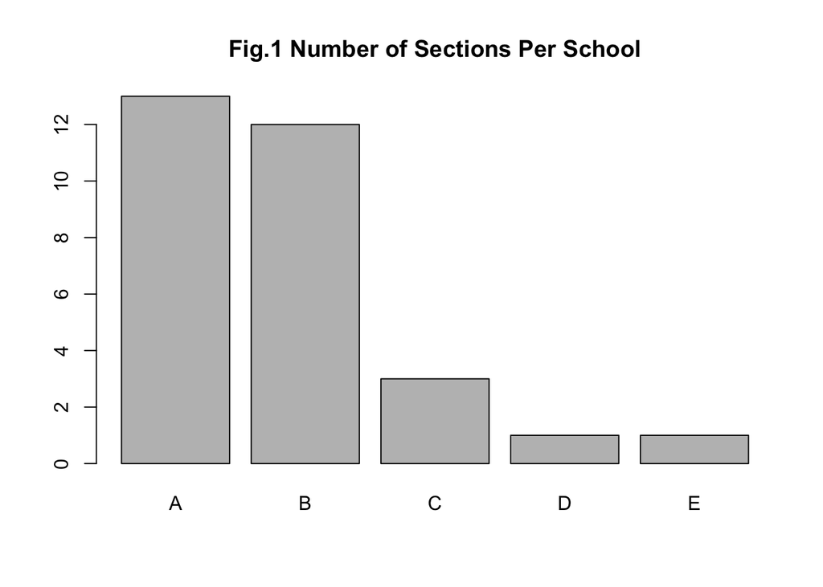

```r
#Create a barplot of the number of sections in each school.
barplot(SchoolNumSections, names.arg = c("A", "B", "C", "D", "E"), main = "Fig.1 Number of Sections Per School")
```

Schools A and B run the most sections of the course (13 and 12), while schools C, D, and E run fewer (school C runs 3 sections while schools D and E only run one section each).

How does the number of students enrolled in the course at each school compare to the number of sections offered?

```r
#How many students in total are in each section?
storyteller$TotalStudents <- rowSums(storyteller[,c(3:8)])
```

Since schools A and B are running the most sections of the course, do they have the most number of students enrolled the course?

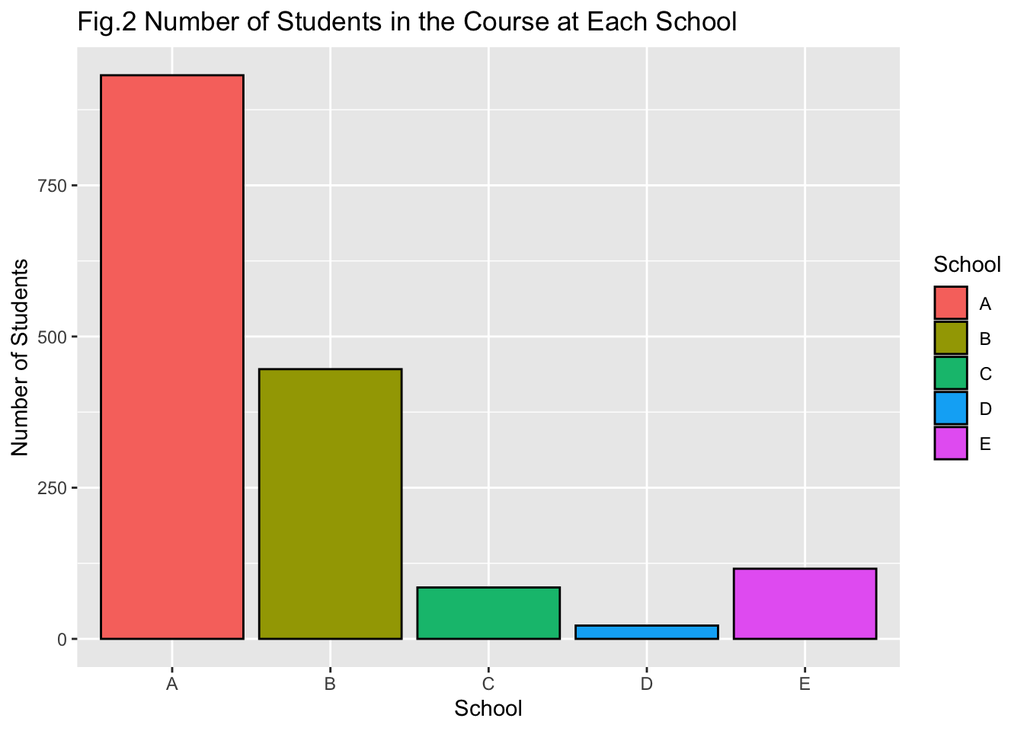

```r
#Bar plot displaying the number of students in the course at each school
storyteller %>%
  group_by(School) %>%
  summarize(StudentsPerSchool = sum(TotalStudents)) %>%
  ggplot(aes(x = School, y = StudentsPerSchool, fill = School)) +
  geom_col(color = "black") +
  labs(y = "Number of Students") +
  ggtitle("Fig.2 Number of Students in the Course at Each School")
```

School A has the greatest number of students enrolled in the course by far, with school B having the second greatest number of students. This is in line with the previous results. Interestingly, school E has more students enrolled than school C, even though school C is running three sections while school E is only running one section.

The total number of students taking the course at each school is only a small piece of the greater picture.

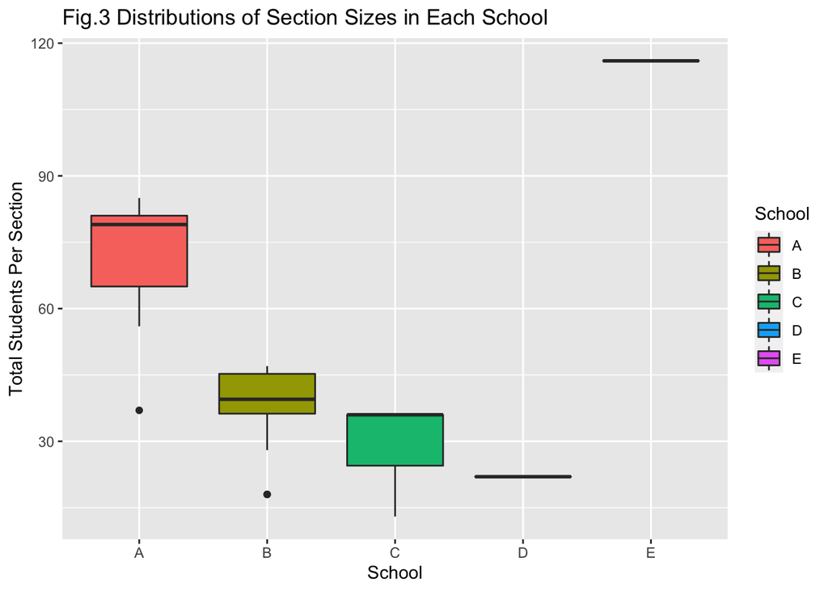

```r
#Box plot showing distribution of section sizes at each school.
storyteller %>%
  ggplot(aes(x = School, y = TotalStudents, fill = School)) +
  geom_boxplot() +
  labs(y = "Total Students Per Section") +
  ggtitle("Fig.3 Distributions of Section Sizes in Each School")
```

Figure 3 shows the distribution of class section sizes at each of the schools. The side-by-side box plots reveal that the one section at school E has the largest class size by far. In general, the class sizes at school A are the second largest, while those at school B are the third largest. Schools C and D have the smallest class sizes. School C has a section of 13 students and school D’s one section has 22 students.

The box plots also reveal the presence of two outliers (one at school A and one at school B). Since the dataset contains so few observations, the outliers will not be removed. However, to address their influence over the measures of central tendency, the median will be used when summarizing the data instead of the mean.

Figure 4 emphasizes the median section sizes by school that are revealed in Figure 3.

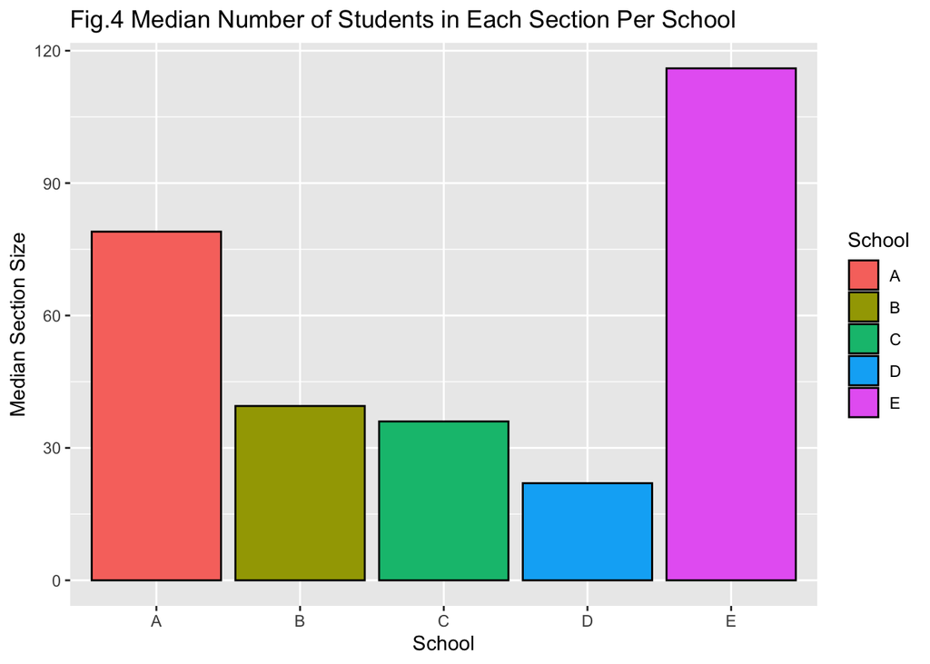

```r
#What is the median section size at each school?
storyteller %>%
  group_by(School) %>%
  summarize(medianSectionSize = median(TotalStudents)) %>%
  ggplot(aes(x = School, y = medianSectionSize, fill = School)) +
  geom_col(color = "black") +
  labs(y = "Median Section Size") +
  ggtitle("Fig.4 Median Number of Students in Each Section Per School")
```

If the courses are being administered in an identical fashion, the students can also be grouped by their progress category instead of by school.

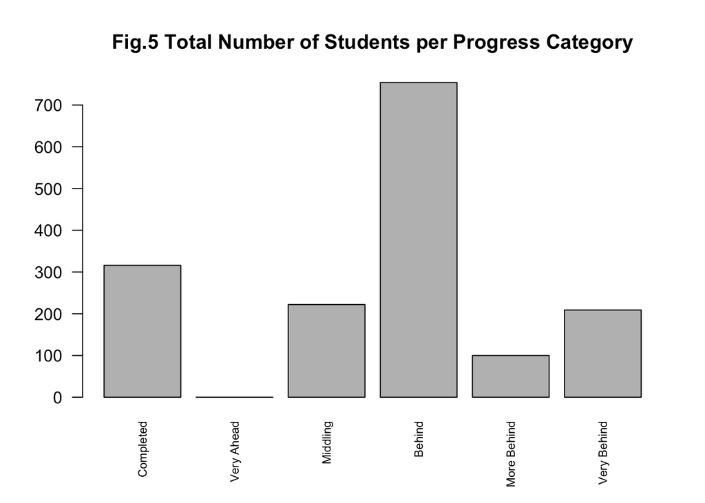

```r
#Creating a vector containing the total number of students in each progress category
storytellerSums <- c(sum(storyteller$Completed), sum(storyteller$VeryAhead), sum(storyteller$Middling), sum(storyteller$Behind), sum(storyteller$MoreBehind), sum(storyteller$VeryBehind))

#Creating a bar plot visualizing how many students are in each progress category
barplot(storytellerSums, names.arg = c("Completed", "Very Ahead", "Middling", "Behind", "More Behind", "Very Behind"), las = 2, cex.names = 0.7, main = "Fig.5 Total Number of Students per Progress Category")
```

In general, an overwhelming number of students are behind. If the progress distributions are different across the various schools then this is evidence that there may be an equity issue in the way the course is being administered.

Of note is that none of the students in any section at any school are more than 5 lessons ahead, but not finished with the course. This may be because the semester is about 75% completed, so students who would be very much ahead at earlier points in the semester may by now have elected to finish the course.

Since the schools have vastly different numbers of students taking the course, the overall progress of the students in each section will be judged by the percentage of students in each section that fall into each of the progress categories. This will allow for a fairer comparison of the sections that has no reliance on the total number of students in each section.

```r
#Convert each row to a percentage of students in that category out of total students
storytellerPercents <- storyteller
storytellerPercents$Completed <- round(((storytellerPercents$Completed / storytellerPercents$TotalStudents) * 100), 2)
storytellerPercents$VeryAhead <- round(((storytellerPercents$VeryAhead / storytellerPercents$TotalStudents) * 100), 2)
storytellerPercents$Middling <- round(((storytellerPercents$Middling / storytellerPercents$TotalStudents) * 100), 2)
storytellerPercents$Behind <- round(((storytellerPercents$Behind / storytellerPercents$TotalStudents) * 100), 2)
storytellerPercents$MoreBehind <- round(((storytellerPercents$MoreBehind / storytellerPercents$TotalStudents) * 100), 2)
storytellerPercents$VeryBehind <- round(((storytellerPercents$VeryBehind / storytellerPercents$TotalStudents) * 100), 2)

#Check to make sure percentage conversion worked. Percents should add to approximately 100, may not be exact due to rounding.
rowSums(storytellerPercents[,c(3:8)])
```

```
##  [1] 100.00 100.00 100.00  99.99 100.00 100.00 100.00  99.99 100.00  99.99
## [11] 100.00 100.01 100.01 100.00 100.01 100.01 100.00 100.00 100.00 100.00
## [21] 100.00 100.00  99.99 100.00 100.01 100.01 100.00  99.99 100.00 100.00
```

```r
#Restructure the data frame to allow for side by side box plots.
storytellerPercentsMelt <- melt(storytellerPercents, id.vars = c("Section", "School", "TotalStudents"), measure.vars = c("Completed", "VeryAhead", "Middling", "Behind", "MoreBehind", "VeryBehind"), factorsAsStrings = FALSE)

#Rename the description of the measure as Progress to represent the progress category.
storytellerPercentsMelt <- storytellerPercentsMelt %>%
  rename(Progress = variable)

#View the restructured data frame.
head(storytellerPercentsMelt)
```

```
##   Section School TotalStudents  Progress value
## 1       1      A            81 Completed 12.35
## 2       2      A            80 Completed  7.50
## 3       3      A            80 Completed 13.75
## 4       4      A            85 Completed 11.76
## 5       5      A            85 Completed  9.41
## 6       6      A            58 Completed 15.52
```

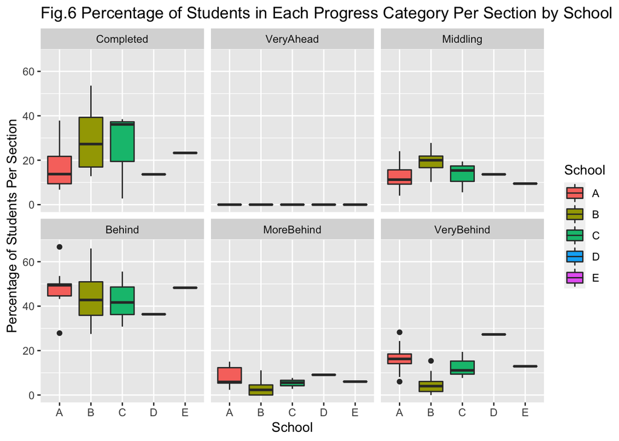

```r
#Each row of this data frame contains the section number and school it belongs to, the total number of students in that section, a label describing the progress category, and the percentage of students in that progress category in that section.

#Creating a box plot to visualize the percentage of students in each progress category
storytellerPercentsMelt %>%
  ggplot(aes(x = School, y = value, fill = School)) +
  geom_boxplot() +
  facet_wrap(~Progress) +
  labs(y = "Percentage of Students Per Section") +
  ggtitle("Fig.6 Percentage of Students in Each Progress Category Per Section by School")
```

At a glance, it appears that the students in each school are performing relatively similarly. For the most part the box plots are overlapping one another, which is evidence that the percentages of students who are in each progress category are not significantly different from one another.

Visualizing the data slightly differently shows what percentage of students at each school are in each progress category.

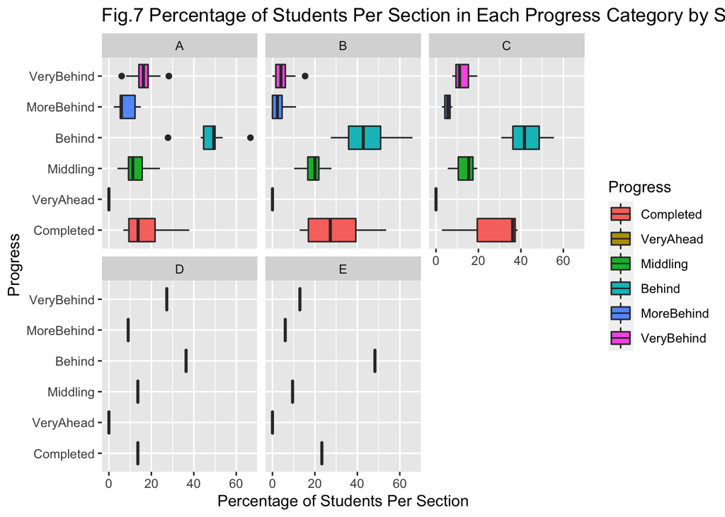

```r
#Creating a box plot to visualize the percentage of students per school in each progress category
storytellerPercentsMelt %>%
  ggplot(aes(x = Progress, y = value, fill = Progress)) +
  geom_boxplot() +
  facet_wrap(~School) +
  labs(y = "Percentage of Students Per Section") +
  ggtitle("Fig.7 Percentage of Students Per Section in Each Progress Category by School") +
  coord_flip()
```

Again, just at a glance, it appears that the greatest percentage of students in each school are behind. In some schools the next greatest percentage of students are completed, while the middling and behind categories are approximately even.

A pattern does emerge, however, by looking only at the median lines in each box plot in Figures 6 and 7. Schools B and C have a greater median percentage of students who are completed compared to all other schools, and have a lower median percentage of students who are in a behind category compared to school A.

## Results

The first question posed for this analysis asks if students in the different schools are performing similarly. The following table shows the median percentage of students at each school who fall into each progress category.

```r
#Summarizing the data to display the median percentage of students in each progress category across each school
storytellerSummary <- storytellerPercents %>%
  group_by(School) %>%
  summarize(medCompleted = median(Completed), medVeryAhead = median(VeryAhead), medMiddling = median(Middling), medBehind = median(Behind), medMoreBehind = median(MoreBehind), medVeryBehind = median(VeryBehind))

print.data.frame(storytellerSummary)
```

```
##   School medCompleted medVeryAhead medMiddling medBehind medMoreBehind
## 1      A       13.750            0       11.25     49.41         5.880
## 2      B       27.265            0       20.00     42.78         2.315
## 3      C       36.110            0       15.38     41.67         5.560
## 4      D       13.640            0       13.64     36.36         9.090
## 5      E       23.280            0        9.48     48.28         6.030
##   medVeryBehind
## 1        16.250
## 2         4.005
## 3        11.110
## 4        27.270
## 5        12.930
```

To further summarize these median values for each progress category, the data is split into two categories: students who are on pace or ahead and students who are behind. The following table shows the median percentage of students at each school who are on pace or ahead, or behind in the course to any degree.

```r
#Condensing the original data into only two categories: those students who are on pace or ahead and those students who are behind to any degree.
storytellerTwoProgress <- storyteller %>%
  transmute(Section, School, OnPaceOrAhead = Completed + VeryAhead + Middling,
            Behind = Behind + MoreBehind + VeryBehind, TotalStudents)

#Changing the raw student counts to the percentage of each section that is on pace/ahead or behind.
storytellerTwoProgress$OnPaceOrAhead = round(((storytellerTwoProgress$OnPaceOrAhead / storytellerTwoProgress$TotalStudents) * 100), 2)
storytellerTwoProgress$Behind = round(((storytellerTwoProgress$Behind / storytellerTwoProgress$TotalStudents) * 100), 2)

#Finding the median percentage of students who are on pace/ahead or behind for each school.
storytellerTwoProgressMedianPercents <- storytellerTwoProgress %>%
  group_by(School) %>%
  summarize(medOnPaceOrAhead = median(OnPaceOrAhead), medBehind = median(Behind))

print.data.frame(storytellerTwoProgressMedianPercents)
```

```
##   School medOnPaceOrAhead medBehind
## 1      A           26.790    73.210
## 2      B           46.665    53.335
## 3      C           41.670    58.330
## 4      D           27.270    72.730
## 5      E           32.760    67.240
```

Although there is some variation from school to school, the median percentage of students who are behind always exceeds the median percentage of students who are on pace or ahead of schedule. However, schools B and C are the closest to having half the students ahead or on pace and half the students behind in each section. Schools A, D, and E are all much closer to having only about 25-30% of students in section ahead or on pace while about 70% of students in each section are behind. This serves as evidence for the trend noticed in Figures 6 and 7 of the Analysis section. While there may be differences in how schools B and C are implementing the course that could be borrowed by schools A, D, and E to help their students improve their performance, there may be an overall difficulty issue with the course since most students are struggling to keep pace at all schools. The optimal difficulty would result in the majority of students being ahead or on pace and a minimal proportion of students falling behind.

A possible explanation for the difference in the number of students who are behind in schools B and C versus schools A, D, and E could be the number of students in each section. Theoretically, if a section contained many students, it would be more difficult for the instructor to attend to all of the students’ needs equitably. Revisiting Figure 4 in the Analysis section shows, however, that while schools B and C do have similar class sizes, that schools A, D, and E all have very different class sizes.

This does not provide any evidence that the percentage of students in each progress category is correlated to the overall size of each section. Figure 8 displays the absence of correlation explicitly.

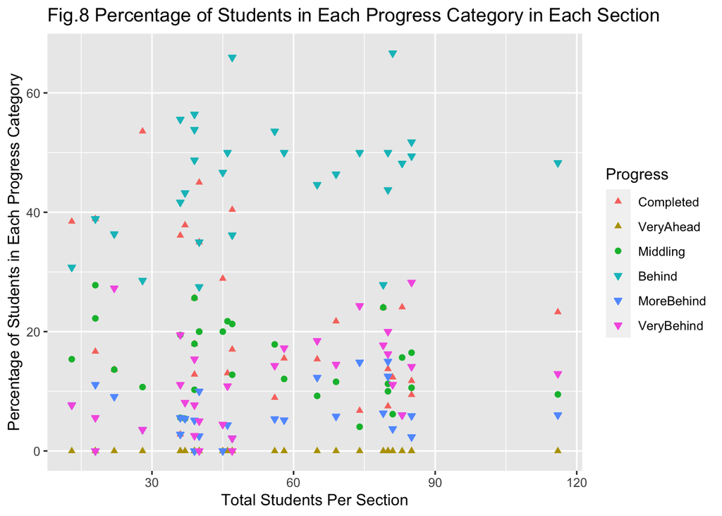

```r
#Creating a scatter plot to explore potential correlation between class size and student progress
storytellerPercentsMelt %>%
  ggplot(aes(x = TotalStudents, y = value, color = Progress, fill = Progress)) +
  geom_point(aes(shape = Progress)) +
  scale_shape_manual(values=c(17, 17, 19, 25, 25, 25)) +
  labs(x = "Total Students Per Section", y = "Percentage of Students in Each Progress Category") +
  ggtitle("Fig.8 Percentage of Students in Each Progress Category in Each Section")
```

First, the scatter plot confirms the patterns related to the student progress categories seen previously. In most sections, the majority of students are in the Behind category, followed by the Completed category, followed by the Middling and the rest of the “behind” categories.

Second, the scatter plot answers the question related to the correlation between progress categories and section size. The progress category is represented by both color and shape. Looking from the left side of the graph to the right and focusing on one type of symbol at a time, one can see that they are grouped as horizontal bands across the coordinate plane. For example, regardless of class size, the percentage of students who are Behind are grouped in a horizontal band along the top portion of the graph, while the percentage of students who are Middling are grouped in a horizontal band inhabiting approximately 10-20% of students per section.

## Conclusions

When administering a course across several schools and sections, the standardization of the course is of paramount importance. Regardless of where a student is taking the course, they should have a similar experience to others. Based on the exploration of the data provided by the five schools offering this math course, it appears that students are struggling. Examining the original six progress categories revealed that the largest proportion of students taking this class are behind, the second largest proportions are either completed or approximately on pace, and then the smallest proportions of students are significantly behind. However, the differences are more easily seen when students are separated into only two groups, those who are ahead or on pace and those who are behind to any degree. Schools B and C had only slightly more students behind than ahead or on pace, while schools A, D, and E had a great majority of students who were behind. The results in either case are unsatisfactory.

These results should serve as a starting point for a discussion about the course structure, lesson quality, administration of those lessons, and pedagogies employed. The course would be considered most successful if all learners are able to access the content and attain and demonstrate mastery of the learning goals contained within. This does not mean that all students are expected to excel, but the great majority of students should remain “on pace” if they attempt to follow the course schedule. In this course however, the great majority of students are some form of “behind”. This could mean that the course is too difficult, that the lessons are not scaffolded properly, or that the lessons do not properly activate students’ prior knowledge so they can feel confident learning the new skills. Based on trends in the U.S., a majority of students are behind in their mathematics education in some way, while there is a small subset who are quite ahead of their peers. This may be a result of the discrepancies found between the experiences of students who are in advanced course tracks versus “regular” tracks. In what may appear as paradoxical, this course appears to be simultaneously too difficult for those who are not comfortable with mathematics and too easy for those who are advanced mathematics students. This leads into the second major issue, which is that a large number of students have already finished the course and will be unengaged for the final 25% of the semester. While the root cause of this issue is further investigated, a quick fix could be to restrict the availability dates on the lessons in the learning management system so students cannot complete everything at once.

The good news is that student difficulties do not appear to be correlated to class size. This means that the responsibility to improve the course does not lie with any individual instructor, but with the course designers and a team of individuals coming from all five schools, who should provide concrete examples describing the reasons why their students have been struggling. This collaboration will be the most effective and efficient way to improve the course for future students.